```python
import pandas as pd
import pickle
```

```python
import os, sys
sys.path.insert(0, os.path.abspath(".."))
```

```python
from src.utils.utils import load_df
from IPython.display import Image
```

# Reporte del proyecto 2, equipo 9

## Modelado:

Se generó un magic loop con los siguientes tres algoritmos, modificando al menos 2 hiperparámetros en cada uno y con al menos 3 configuraciones diferentes. Adicionalmente, se realizó un `Temporal Cross Validation` de 5 a través de un `GridSearchCV`. El criterio de selección del mejor modelo fue la precisión en el punto de corte derivado de las 20 ambulancias con que se cuenta:

- `DecisionTree`
- `RandomForest`
- `Logistic Regression`

De los modelos, se seleccionó el siguiente:

```python
load_df("../output/model_loop.pkl")
```

```
RandomForestClassifier(max_depth=10, min_samples_leaf=8, n_estimators=300,
                       oob_score=True, random_state=2222)
```

## Evaluación del modelo:

Con nuestro mejor modelo, se obtuvo la siguiente curva ROC:

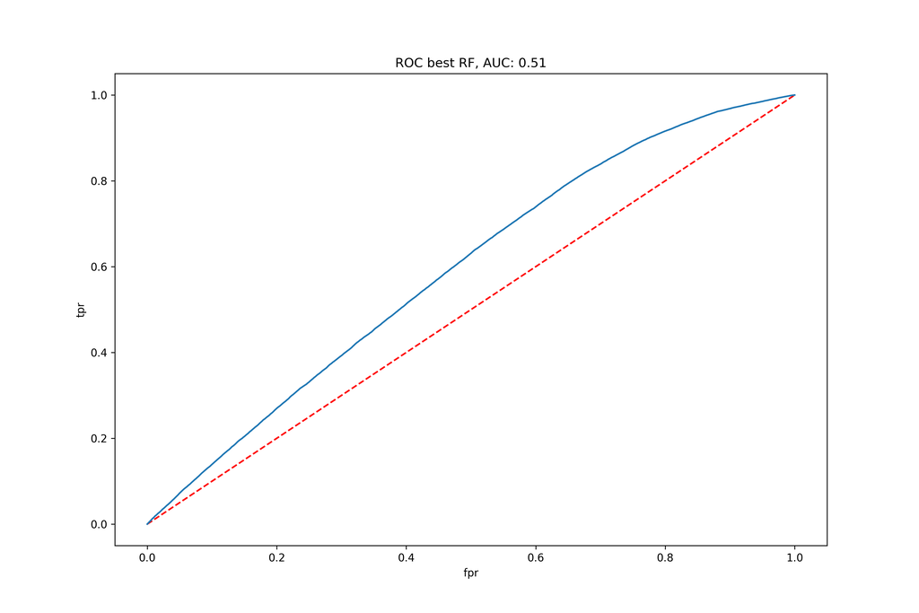

```python
Image("../output/metricas/roc.png")
```

Adicionalmente, se creó la siguiente tabla de métricas:

```python
load_df("../output/metricas/metricas_offline.pkl")
```

|  | threshold | precision | recall | f1_score | tpr | fpr | tnr | fnr |
| --- | --- | --- | --- | --- | --- | --- | --- | --- |
| 0 | 0.012637 | 0.195098 | 1.000000 | 0.326497 | 1.000000 | 0.999829 | 0.000171 | 0.000000 |
| 1 | 0.013152 | 0.195096 | 0.999988 | 0.326494 | 0.999988 | 0.999829 | 0.000171 | 0.000012 |
| 2 | 0.013180 | 0.195096 | 0.999988 | 0.326494 | 0.999988 | 0.999826 | 0.000174 | 0.000012 |
| 3 | 0.013276 | 0.195098 | 0.999975 | 0.326495 | 0.999975 | 0.999805 | 0.000195 | 0.000025 |
| 4 | 0.013834 | 0.195101 | 0.999975 | 0.326500 | 0.999975 | 0.999784 | 0.000216 | 0.000025 |
| ... | ... | ... | ... | ... | ... | ... | ... | ... |
| 3134 | 0.294925 | 0.276316 | 0.009340 | 0.018069 | 0.009340 | 0.005928 | 0.994072 | 0.990660 |
| 3135 | 0.298499 | 0.276166 | 0.005411 | 0.010614 | 0.005411 | 0.003437 | 0.996563 | 0.994589 |
| 3136 | 0.302256 | 0.276341 | 0.005411 | 0.010615 | 0.005411 | 0.003434 | 0.996566 | 0.994589 |
| 3137 | 0.304941 | 0.283711 | 0.003249 | 0.006425 | 0.003249 | 0.001988 | 0.998012 | 0.996751 |
| 3138 | 0.337046 | 0.333333 | 0.000012 | 0.000025 | 0.000012 | 0.000006 | 0.999994 | 0.999988 |

3139 rows × 8 columns

- Para consultar en su totalidad la tabla, verificar el pickle en la siguiente dirección después de correr completamente el pipeline: `../output/metricas/metricas_offline.pkl`

Con cada K, se obtienen los siguientes resultados para precision y recall:

```python
load_df("../output/metricas/pr_at_k.pkl")
```

|  | k | precision | recall |
| --- | --- | --- | --- |
| 0 | 0.01 | 0.270555 | 0.015529 |
| 1 | 0.02 | 0.261191 | 0.027896 |
| 2 | 0.03 | 0.258745 | 0.039843 |
| 3 | 0.04 | 0.257125 | 0.055842 |
| 4 | 0.05 | 0.257706 | 0.067863 |
| ... | ... | ... | ... |
| 94 | 0.95 | 0.201743 | 0.982506 |
| 95 | 0.96 | 0.200418 | 0.986435 |
| 96 | 0.97 | 0.199121 | 0.990141 |
| 97 | 0.98 | 0.197819 | 0.993860 |
| 98 | 0.99 | 0.196480 | 0.997171 |

99 rows × 3 columns

- Para consultar en su totalidad la tabla, verificar el pickle en la siguiente dirección después de correr completamente el pipeline: `../output/metricas/pr_at_k.pkl`

La curva de **precision-recall** con el modelo seleccionado es la siguiente.

Nótese que la línea vertical color azul indica el valor de K con 20 ambulancias disponibles.

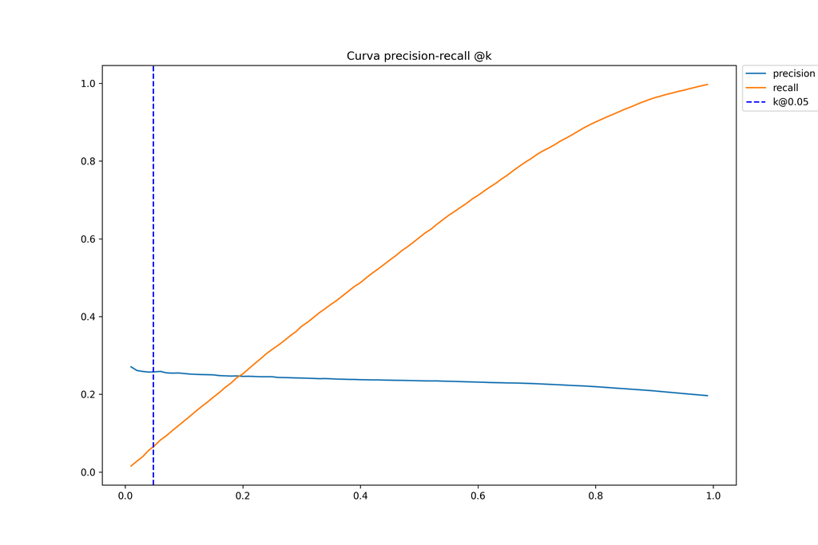

```python
Image("../output/metricas/precision-recall-curve.png")
```

¿Cuánto tienes de cobertura@k? Interpreta

**R =** El valor de cobertura en 0.05 es `0.067863`  
Este score de cobertura se debe a que contamos con pocos recursos para la demanda diaria de llamadas.

¿Cuánto tienes de eficiencia@k? Interpreta

**R =** El valor de eficiencia en 0.05 es `0.257706`  
Para un corte tan bajo, se debería observar una precisión mayor. Sin embargo, resultó dificil obtener un modelo con una buena precisión, por lo que se podría adjudicar una baja capacidad de predicción a los features con los que se cuenta.

¿Cuál es la cobertura máxima que se puede tener con la k que tienes?  
Tomando en cuenta la respuesta a esta pregunta, tu modelo ¿es bueno? ¿es malo?

## Sesgo e Inequidad

Utilizando el feature `delegacion` como atributo protegido:

1. Selecciona 3 métricas adecuadas de acuerdo a los objetivos y acciones.
   - Dado que nuestro modelo es **punitivo** (no brindamos servicio de ambulacias a personas para auxiliarlas en caso de pronosticar una llamada falsa o 1), seleccionamos las métricas:
     - FPR - Es de interés por que es una llamada a la que se le negó la ambulancia debido a la delegación desde donde se realiza el reporte.
     - FDR - Esta imploca que, dada una llamada a la que se le negó ambulancia, ¿cuál es la probabilidad de que si fuera requerida dada la delegación? por lo que resulta de interés.
     - FOR - Esta última es de interés, ya que implica que enviamos una ambulancia a un lugar que no lo requería.
   - Nota: Dados nuestros resultados de capacidad predictiva, no pudimos evaluar estas tres métricas, por lo que se reportan:
     - FOR - False Omission Rate.
     - NPV - Negative Predictive Value.
     - PREV - Group Prevalence.
1. Define cuál es tu grupo de referencia. Justifica.
   - Utilizaremos la delegación de Iztapalapa ya que en los datos históricos del set es el grupo con mayor número de observaciones y también es el grupo al que mayor cantidad de ambulancias se han mandado como falsa alarma.
1. Cuantifica el sesgo e inequidad sobre los grupos de este atributo.

### Clase Group

Tabla de la clase group para conteo de frecuencias

```python
load_df("../output/aequitas/df_group_frecuencias_path.pkl")
```

|  | model_id | score_threshold | k | attribute_name | attribute_value | pp | pn | fp | fn | tn | tp | group_label_pos | group_label_neg | group_size | total_entities |
| --- | --- | --- | --- | --- | --- | --- | --- | --- | --- | --- | --- | --- | --- | --- | --- |
| 0 | 0 | binary 0/1 | 0 | delegacion | alvaro obregon | 0 | 29968 | 0 | 6439 | 23529 | 0 | 6439 | 23529 | 29968 | 414941 |
| 1 | 0 | binary 0/1 | 0 | delegacion | azcapotzalco | 0 | 18114 | 0 | 2793 | 15321 | 0 | 2793 | 15321 | 18114 | 414941 |
| 2 | 0 | binary 0/1 | 0 | delegacion | benito juarez | 0 | 31184 | 0 | 4807 | 26377 | 0 | 4807 | 26377 | 31184 | 414941 |
| 3 | 0 | binary 0/1 | 0 | delegacion | coyoacan | 0 | 31673 | 0 | 6766 | 24907 | 0 | 6766 | 24907 | 31673 | 414941 |
| 4 | 0 | binary 0/1 | 0 | delegacion | cuajimalpa | 0 | 7838 | 0 | 2479 | 5359 | 0 | 2479 | 5359 | 7838 | 414941 |
| 5 | 0 | binary 0/1 | 0 | delegacion | cuauhtemoc | 0 | 41549 | 0 | 5843 | 35706 | 0 | 5843 | 35706 | 41549 | 414941 |
| 6 | 0 | binary 0/1 | 0 | delegacion | gustavo a. madero | 0 | 41332 | 0 | 7666 | 33666 | 0 | 7666 | 33666 | 41332 | 414941 |
| 7 | 0 | binary 0/1 | 0 | delegacion | iztacalco | 0 | 17444 | 0 | 3241 | 14203 | 0 | 3241 | 14203 | 17444 | 414941 |
| 8 | 0 | binary 0/1 | 0 | delegacion | iztapalapa | 0 | 69233 | 0 | 15175 | 54058 | 0 | 15175 | 54058 | 69233 | 414941 |
| 9 | 0 | binary 0/1 | 0 | delegacion | magdalena contreras | 0 | 6639 | 0 | 1761 | 4878 | 0 | 1761 | 4878 | 6639 | 414941 |
| 10 | 0 | binary 0/1 | 0 | delegacion | miguel hidalgo | 0 | 31285 | 0 | 5819 | 25466 | 0 | 5819 | 25466 | 31285 | 414941 |
| 11 | 0 | binary 0/1 | 0 | delegacion | milpa alta | 0 | 2340 | 0 | 558 | 1782 | 0 | 558 | 1782 | 2340 | 414941 |
| 12 | 0 | binary 0/1 | 0 | delegacion | tlahuac | 0 | 10591 | 0 | 2320 | 8271 | 0 | 2320 | 8271 | 10591 | 414941 |
| 13 | 0 | binary 0/1 | 0 | delegacion | tlalpan | 0 | 29816 | 0 | 6014 | 23802 | 0 | 6014 | 23802 | 29816 | 414941 |
| 14 | 0 | binary 0/1 | 0 | delegacion | venustiano carranza | 0 | 29010 | 0 | 5355 | 23655 | 0 | 5355 | 23655 | 29010 | 414941 |
| 15 | 0 | binary 0/1 | 0 | delegacion | xochimilco | 0 | 16925 | 0 | 3907 | 13018 | 0 | 3907 | 13018 | 16925 | 414941 |

Tabla de la clase group para conteo de métricas absolutas.

```python
load_df("../output/aequitas/df_group_absolutas_path.pkl")
```

|  | attribute_name | attribute_value | tpr | tnr | for | fdr | fpr | fnr | npv | precision | ppr | pprev | prev |
| --- | --- | --- | --- | --- | --- | --- | --- | --- | --- | --- | --- | --- | --- |
| 0 | delegacion | alvaro obregon | 0.0 | 1.0 | 0.21 | NaN | 0.0 | 1.0 | 0.79 | NaN | NaN | 0.0 | 0.21 |
| 1 | delegacion | azcapotzalco | 0.0 | 1.0 | 0.15 | NaN | 0.0 | 1.0 | 0.85 | NaN | NaN | 0.0 | 0.15 |
| 2 | delegacion | benito juarez | 0.0 | 1.0 | 0.15 | NaN | 0.0 | 1.0 | 0.85 | NaN | NaN | 0.0 | 0.15 |
| 3 | delegacion | coyoacan | 0.0 | 1.0 | 0.21 | NaN | 0.0 | 1.0 | 0.79 | NaN | NaN | 0.0 | 0.21 |
| 4 | delegacion | cuajimalpa | 0.0 | 1.0 | 0.32 | NaN | 0.0 | 1.0 | 0.68 | NaN | NaN | 0.0 | 0.32 |
| 5 | delegacion | cuauhtemoc | 0.0 | 1.0 | 0.14 | NaN | 0.0 | 1.0 | 0.86 | NaN | NaN | 0.0 | 0.14 |
| 6 | delegacion | gustavo a. madero | 0.0 | 1.0 | 0.19 | NaN | 0.0 | 1.0 | 0.81 | NaN | NaN | 0.0 | 0.19 |
| 7 | delegacion | iztacalco | 0.0 | 1.0 | 0.19 | NaN | 0.0 | 1.0 | 0.81 | NaN | NaN | 0.0 | 0.19 |
| 8 | delegacion | iztapalapa | 0.0 | 1.0 | 0.22 | NaN | 0.0 | 1.0 | 0.78 | NaN | NaN | 0.0 | 0.22 |
| 9 | delegacion | magdalena contreras | 0.0 | 1.0 | 0.27 | NaN | 0.0 | 1.0 | 0.73 | NaN | NaN | 0.0 | 0.27 |
| 10 | delegacion | miguel hidalgo | 0.0 | 1.0 | 0.19 | NaN | 0.0 | 1.0 | 0.81 | NaN | NaN | 0.0 | 0.19 |
| 11 | delegacion | milpa alta | 0.0 | 1.0 | 0.24 | NaN | 0.0 | 1.0 | 0.76 | NaN | NaN | 0.0 | 0.24 |
| 12 | delegacion | tlahuac | 0.0 | 1.0 | 0.22 | NaN | 0.0 | 1.0 | 0.78 | NaN | NaN | 0.0 | 0.22 |
| 13 | delegacion | tlalpan | 0.0 | 1.0 | 0.20 | NaN | 0.0 | 1.0 | 0.80 | NaN | NaN | 0.0 | 0.20 |
| 14 | delegacion | venustiano carranza | 0.0 | 1.0 | 0.18 | NaN | 0.0 | 1.0 | 0.82 | NaN | NaN | 0.0 | 0.18 |
| 15 | delegacion | xochimilco | 0.0 | 1.0 | 0.23 | NaN | 0.0 | 1.0 | 0.77 | NaN | NaN | 0.0 | 0.23 |

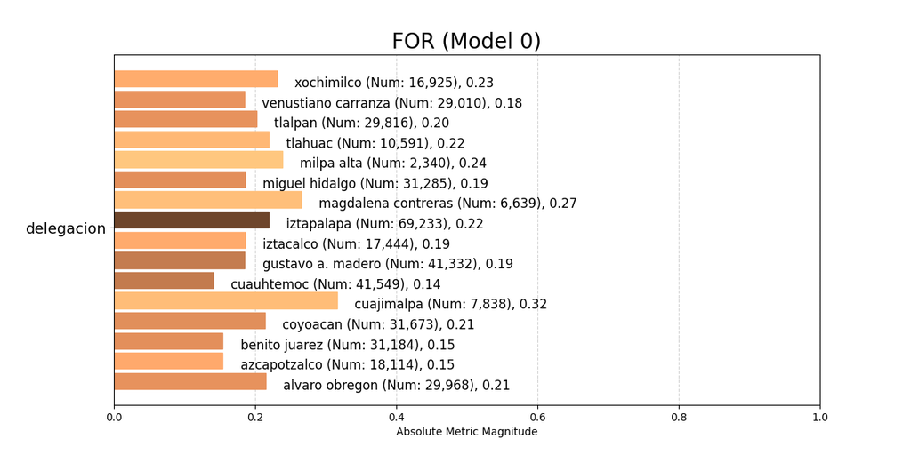

```python
Image("../output/aequitas/group_FOR_plot.png")
```

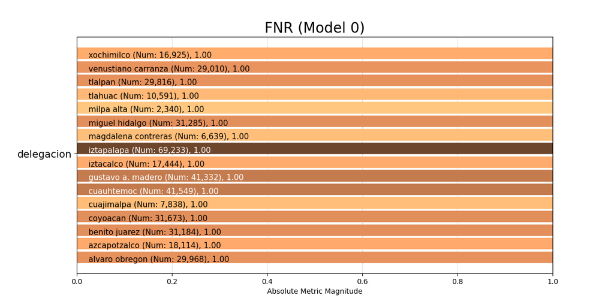

```python
Image("../output/aequitas/group_FNR_plot.png")
```

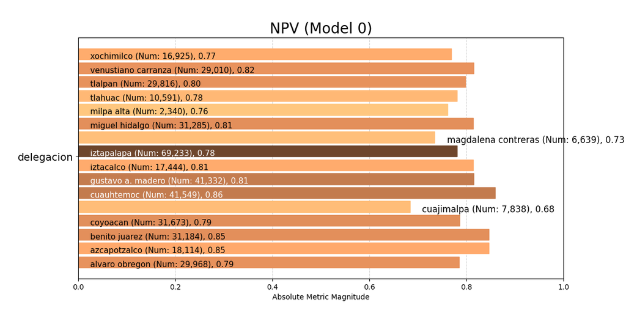

```python
Image("../output/aequitas/group_NPV_plot.png")
```

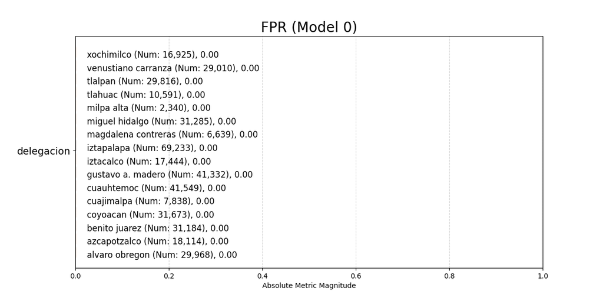

```python
Image("../output/aequitas/group_FPR_plot.png")
```

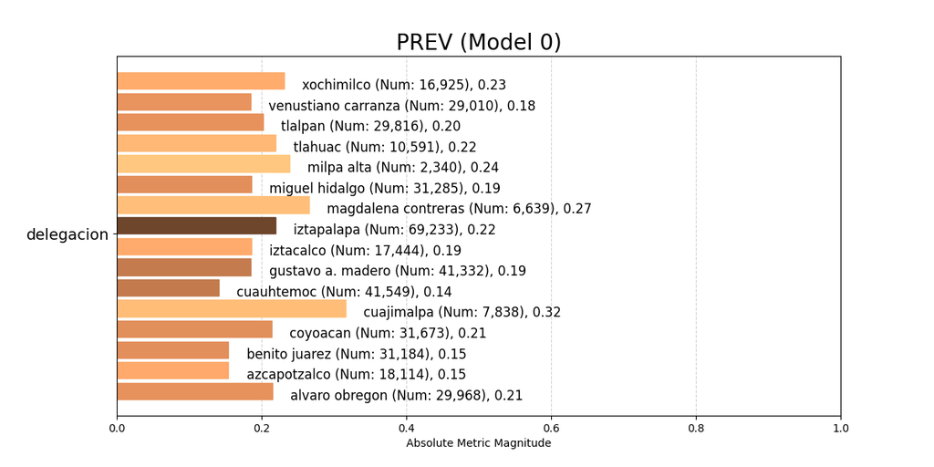

```python
Image("../output/aequitas/group_PREV_plot.png")
```

### Clase Bias

Tabla de métricas de disparidad:

```python
load_df("../output/aequitas/df_disparidad_limpio_path.pkl")
```

|  | attribute_name | attribute_value | for_disparity | fnr_disparity | tnr_disparity | npv_disparity |
| --- | --- | --- | --- | --- | --- | --- |
| 0 | delegacion | alvaro obregon | 0.98 | 1.0 | 1.0 | 1.01 |
| 1 | delegacion | azcapotzalco | 0.70 | 1.0 | 1.0 | 1.08 |
| 2 | delegacion | benito juarez | 0.70 | 1.0 | 1.0 | 1.08 |
| 3 | delegacion | coyoacan | 0.97 | 1.0 | 1.0 | 1.01 |
| 4 | delegacion | cuajimalpa | 1.44 | 1.0 | 1.0 | 0.88 |
| 5 | delegacion | cuauhtemoc | 0.64 | 1.0 | 1.0 | 1.10 |
| 6 | delegacion | gustavo a. madero | 0.85 | 1.0 | 1.0 | 1.04 |
| 7 | delegacion | iztacalco | 0.85 | 1.0 | 1.0 | 1.04 |
| 8 | delegacion | iztapalapa | 1.00 | 1.0 | 1.0 | 1.00 |
| 9 | delegacion | magdalena contreras | 1.21 | 1.0 | 1.0 | 0.94 |
| 10 | delegacion | miguel hidalgo | 0.85 | 1.0 | 1.0 | 1.04 |
| 11 | delegacion | milpa alta | 1.09 | 1.0 | 1.0 | 0.98 |
| 12 | delegacion | tlahuac | 1.00 | 1.0 | 1.0 | 1.00 |
| 13 | delegacion | tlalpan | 0.92 | 1.0 | 1.0 | 1.02 |
| 14 | delegacion | venustiano carranza | 0.84 | 1.0 | 1.0 | 1.04 |
| 15 | delegacion | xochimilco | 1.05 | 1.0 | 1.0 | 0.99 |

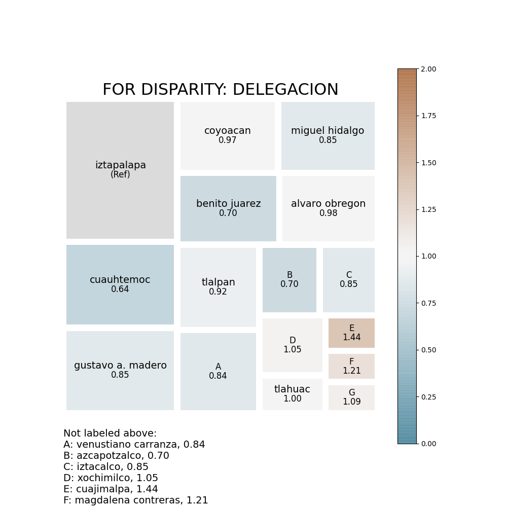

```python
Image("../output/aequitas/bias_FOR_DISPARITY_plot.png")
```

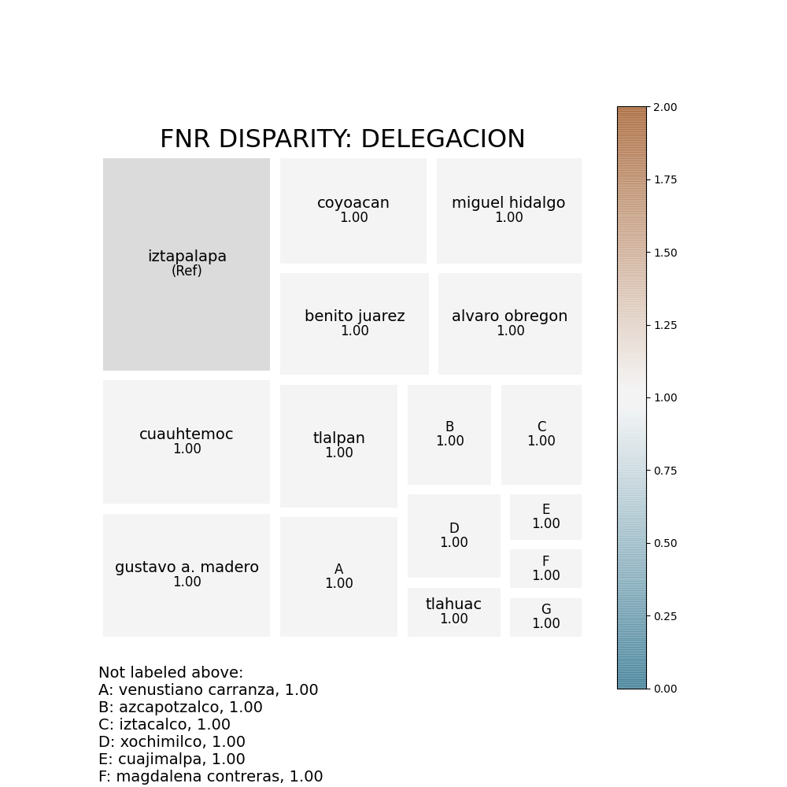

```python
Image("../output/aequitas/bias_FNR_DISPARITY_plot.png")
```

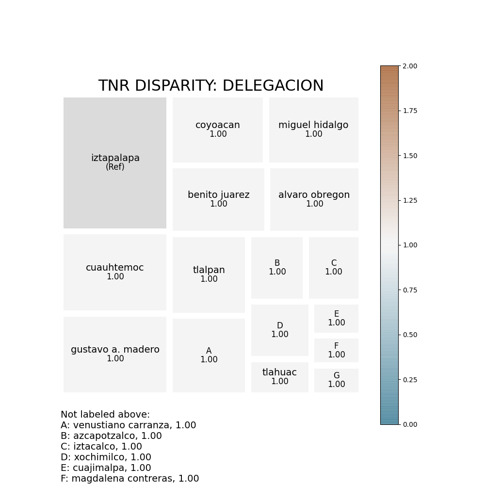

```python
Image("../output/aequitas/bias_TNR_DISPARITY_plot.png")
```

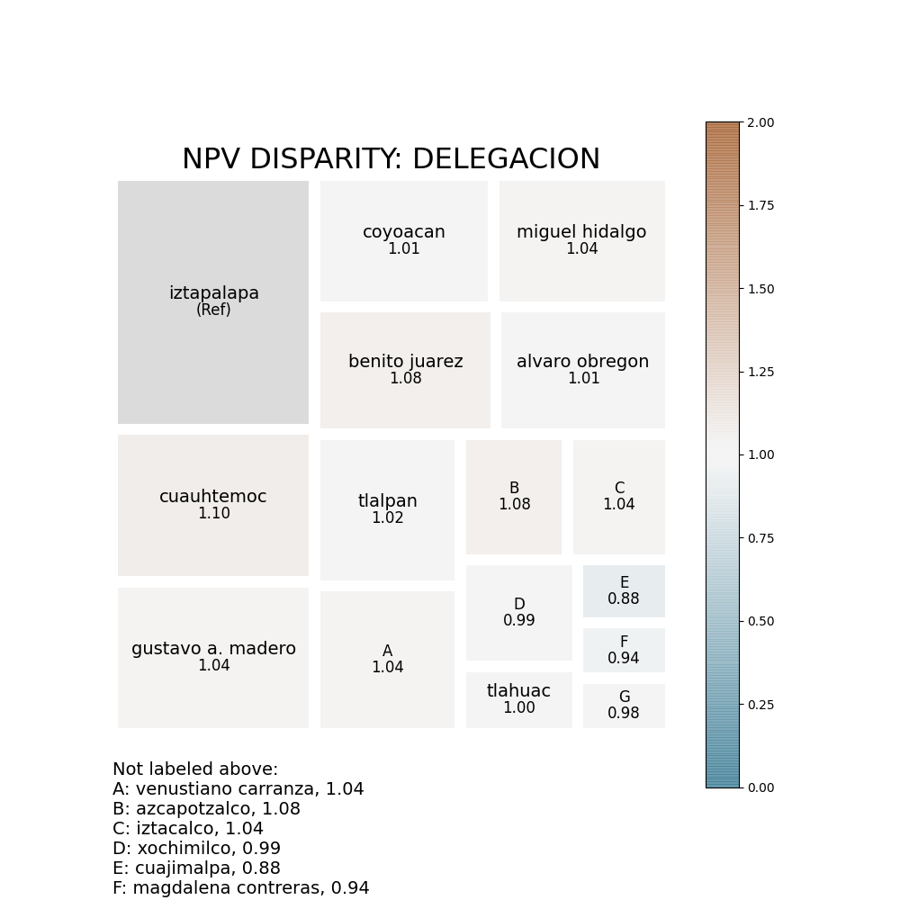

```python
Image("../output/aequitas/bias_NPV_DISPARITY_plot.png")
```

### Clase Fairness

Tabla de métricas de equidad por grupos:

```python
load_df("../output/aequitas/fairness_result_path.pkl")
```

|  | attribute_name | attribute_value | tpr | tnr | for | fdr | fpr | fnr | npv | precision | ... | TNR Parity | TypeI Parity | Equalized Odds | Supervised Fairness | Unsupervised Fairness | TypeII Parity | Statistical Parity | FDR Parity | FNR Parity | Precision Parity |
| --- | --- | --- | --- | --- | --- | --- | --- | --- | --- | --- | --- | --- | --- | --- | --- | --- | --- | --- | --- | --- | --- |
| 0 | delegacion | alvaro obregon | 0.0 | 1.0 | 0.21 | NaN | 0.0 | 1.0 | 0.79 | NaN | ... | True | NaN | NaN | False | NaN | True | NaN | NaN | True | NaN |
| 1 | delegacion | azcapotzalco | 0.0 | 1.0 | 0.15 | NaN | 0.0 | 1.0 | 0.85 | NaN | ... | True | NaN | NaN | False | NaN | False | NaN | NaN | True | NaN |
| 2 | delegacion | benito juarez | 0.0 | 1.0 | 0.15 | NaN | 0.0 | 1.0 | 0.85 | NaN | ... | True | NaN | NaN | False | NaN | False | NaN | NaN | True | NaN |
| 3 | delegacion | coyoacan | 0.0 | 1.0 | 0.21 | NaN | 0.0 | 1.0 | 0.79 | NaN | ... | True | NaN | NaN | False | NaN | True | NaN | NaN | True | NaN |
| 4 | delegacion | cuajimalpa | 0.0 | 1.0 | 0.32 | NaN | 0.0 | 1.0 | 0.68 | NaN | ... | True | NaN | NaN | False | NaN | False | NaN | NaN | True | NaN |
| 5 | delegacion | cuauhtemoc | 0.0 | 1.0 | 0.14 | NaN | 0.0 | 1.0 | 0.86 | NaN | ... | True | NaN | NaN | False | NaN | False | NaN | NaN | True | NaN |
| 6 | delegacion | gustavo a. madero | 0.0 | 1.0 | 0.19 | NaN | 0.0 | 1.0 | 0.81 | NaN | ... | True | NaN | NaN | False | NaN | True | NaN | NaN | True | NaN |
| 7 | delegacion | iztacalco | 0.0 | 1.0 | 0.19 | NaN | 0.0 | 1.0 | 0.81 | NaN | ... | True | NaN | NaN | False | NaN | True | NaN | NaN | True | NaN |
| 8 | delegacion | iztapalapa | 0.0 | 1.0 | 0.22 | NaN | 0.0 | 1.0 | 0.78 | NaN | ... | True | NaN | NaN | False | NaN | True | NaN | NaN | True | NaN |
| 9 | delegacion | magdalena contreras | 0.0 | 1.0 | 0.27 | NaN | 0.0 | 1.0 | 0.73 | NaN | ... | True | NaN | NaN | False | NaN | True | NaN | NaN | True | NaN |
| 10 | delegacion | miguel hidalgo | 0.0 | 1.0 | 0.19 | NaN | 0.0 | 1.0 | 0.81 | NaN | ... | True | NaN | NaN | False | NaN | True | NaN | NaN | True | NaN |
| 11 | delegacion | milpa alta | 0.0 | 1.0 | 0.24 | NaN | 0.0 | 1.0 | 0.76 | NaN | ... | True | NaN | NaN | False | NaN | True | NaN | NaN | True | NaN |
| 12 | delegacion | tlahuac | 0.0 | 1.0 | 0.22 | NaN | 0.0 | 1.0 | 0.78 | NaN | ... | True | NaN | NaN | False | NaN | True | NaN | NaN | True | NaN |
| 13 | delegacion | tlalpan | 0.0 | 1.0 | 0.20 | NaN | 0.0 | 1.0 | 0.80 | NaN | ... | True | NaN | NaN | False | NaN | True | NaN | NaN | True | NaN |
| 14 | delegacion | venustiano carranza | 0.0 | 1.0 | 0.18 | NaN | 0.0 | 1.0 | 0.82 | NaN | ... | True | NaN | NaN | False | NaN | True | NaN | NaN | True | NaN |
| 15 | delegacion | xochimilco | 0.0 | 1.0 | 0.23 | NaN | 0.0 | 1.0 | 0.77 | NaN | ... | True | NaN | NaN | False | NaN | True | NaN | NaN | True | NaN |

16 rows × 38 columns

Tabla de métricas de equidad por atributos:

```python
load_df("../output/aequitas/fairness_gaf_path.pkl")
```

|  | model_id | score_threshold | attribute_name | Statistical Parity | Impact Parity | FDR Parity | FPR Parity | FOR Parity | FNR Parity | TPR Parity | TNR Parity | NPV Parity | Precision Parity | TypeI Parity | TypeII Parity | Equalized Odds | Unsupervised Fairness | Supervised Fairness |
| --- | --- | --- | --- | --- | --- | --- | --- | --- | --- | --- | --- | --- | --- | --- | --- | --- | --- | --- |
| 0 | 0 | binary 0/1 | delegacion | NaN | NaN | NaN | NaN | False | True | NaN | True | True | NaN | NaN | False | NaN | NaN | False |

Tabla de métricas de equidad por global:

```python
load_df("../output/aequitas/fairness_gof_path.pkl")
```

```
{'Unsupervised Fairness': True,
 'Supervised Fairness': False,
 'Overall Fairness': False}
```

Gráfica de Equidad de FOR (False Omission Rate)

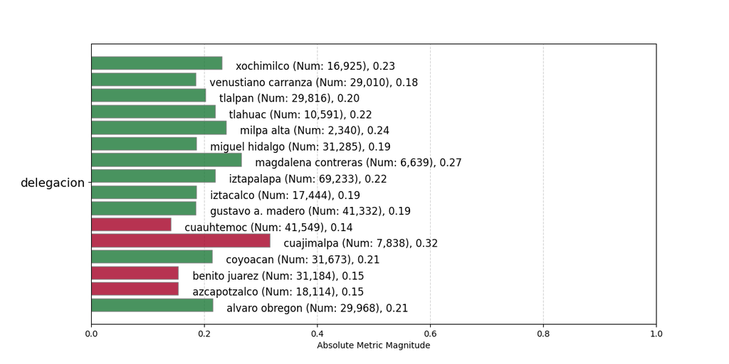

```python
Image("../output/aequitas/fairness_FOR_plot.png")
```

Gráfica de Equidad de FNR (False Negative Rate)

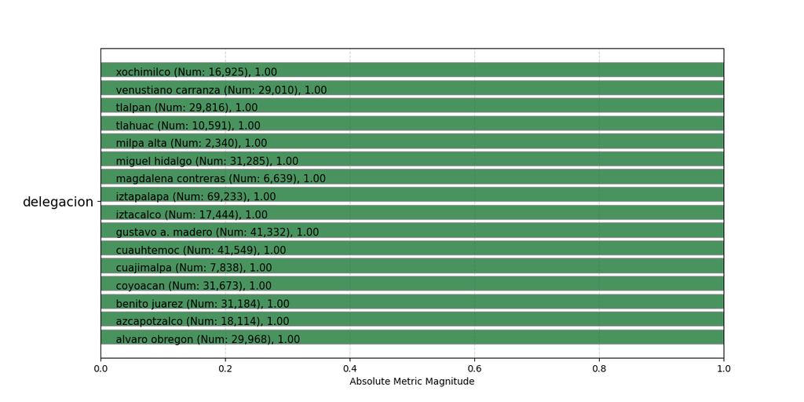

```python
Image("../output/aequitas/fairness_FNR_plot.png")
```

Gráfica de Equidad de TNR (True Negative Rate)

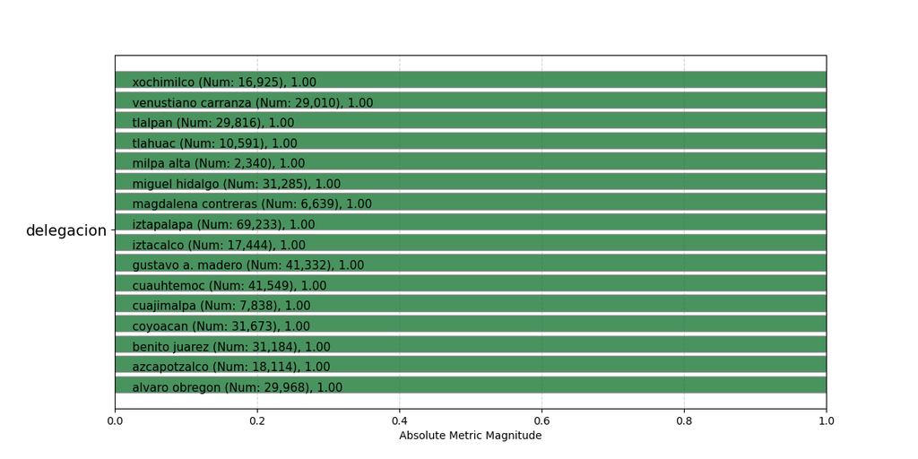

```python
Image("../output/aequitas/fairness_TNR_plot.png")
```

Gráfica de Equidad de NPV (Negative Predictive Value)

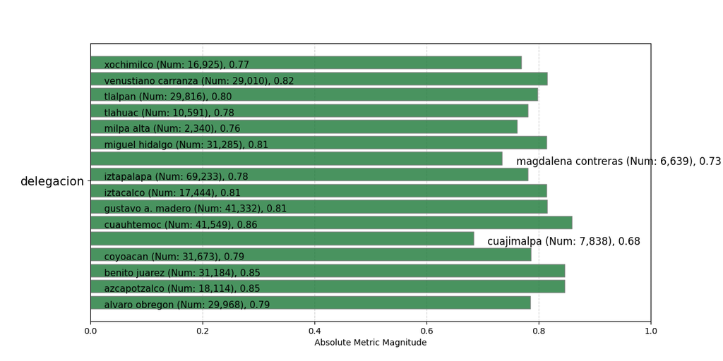

```python
Image("../output/aequitas/fairness_NPV_plot.png")
```